# ESM204 Assignment 3

Simone Albuquerque, Claudia Flores, and Anthony Luna

```r
#readin Data
cost_gas_data<- read_csv("assign_3_data.csv") %>%
  clean_names()
```

```r
# Linear Regression Low Cost Consumer
lm_low <- lm(price_dollars ~ q_low_gallons, data=cost_gas_data)
#print(lm_low)  #  1.169e+01 + -6.611e-05*q
# Linear Regression High Cost Consumer
lm_high <- lm(price_dollars ~ q_high_gallons, data=cost_gas_data)
#print(lm_high)  #  1.580e+01 + -2.731e-05*q
# Linear Regression Aggregate Cost Consumer
lm_agg <- lm(price_dollars ~ q_aggregrate, data=cost_gas_data)
#print(lm_agg)  #  1.500e+01 + -2.043e-05*q
```

```r
# Demand Curve Coefficients based on linear models
I1<-  lm_low$coefficients[1]
I2<-  lm_high$coefficients[1]
S1<-  lm_low$coefficients[2]
S2<-  lm_high$coefficients[2]

# functional definition of high and low demand based on linear model
low_demand <- function(q)  I1 + (S1*q)
high_demand <- function(q) I2 + (S2*q)

# in Q = P format 8 for consumer surplus calculations
inverse_low_demand<- function(p) (p-I1)/S1
inverse_high_demand<- function(p) (p-I2)/S2

# Determines the 'dominate' curve. This only works for linear models
demand_dom <- function(q){
  if (I1==I2){0}
  else if(I1>I2){low_demand(q)}
  else if(I2>I1){high_demand(q)}
}
# Determines q such that high demand and low demand are equal. Used to find
# the kink in the curve.
intersect_point <- abs(uniroot(function(q){high_demand(q)-low_demand(0)},
                            interval = c(-1,1),extendInt = "yes")$root)

# functional defintion of aggregate demand
# the function itself. When q is less than the interset, returns the 'dominant'
agg_demand <- function(q) {ifelse(q<intersect_point,demand_dom(q),((S2*I1+S1*I2)/(S2+S1))+((S1*S2)/(S1+S2))*q)
                                  #lm_agg$coefficients[1] + (lm_agg$coefficients[2]*q))
}

demand_dom_x_intersect <- uniroot(demand_dom,
                                  interval = c(0,1),
                                  extendInt = "yes")$root
# finding the supply curve requires us to find the point at which the agg curve the price is
# equal to three. We know the current price is untaxed and equal to three.
current_price <- 3
supply_agg_intersect <- uniroot(function(q){agg_demand(q)-current_price}, interval = c(0,1), extendInt = "yes")$root
supply_slope <- current_price/supply_agg_intersect
# functional definition of Supply
supply <- function(q){q*supply_slope}

#functional definition of environmental costs
local_env_cost_curve<- function(q) 1.5 + (.0000*q) # local MEC $ 1.50
global_env_cost_curve<- function(q) .50 + (.0000*q) # global MEC $.50
total_env_cost_curve<- function(q) 2+ (.0000*q)# total MEC $.50
```

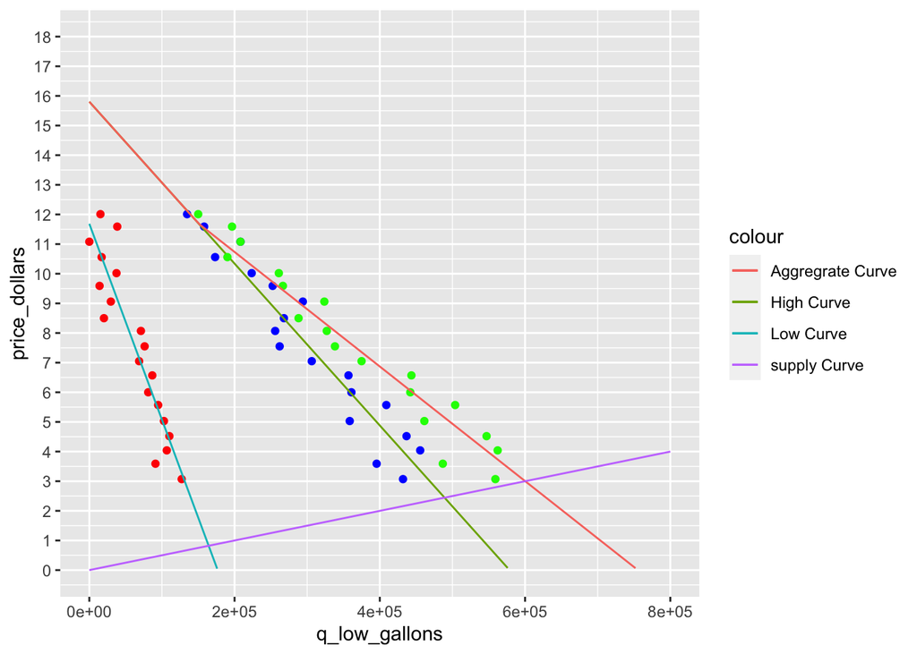

```r
ggplot()+
  geom_point(data = cost_gas_data, aes(x= q_low_gallons, y = price_dollars),color="red")+
  stat_function(aes(x=0, color = "Low Curve"), fun = low_demand)+
  geom_point(data = cost_gas_data, aes(x= q_high_gallons, y = price_dollars),color="blue")+
  stat_function(aes(x=0, color = "High Curve"), fun = high_demand)+
  geom_point(data = cost_gas_data, aes(x= q_aggregrate, y = price_dollars),color="green")+
  stat_function(aes(x=0, color = "Aggregrate Curve"), fun = agg_demand)+
  stat_function(aes(x=0, color = "supply Curve"), fun = supply)  +
  xlim(0,800000)+
  scale_y_continuous(breaks=seq(from=0,to=18,by=1),limits = c(0,18))
```

1. Answer the following Questions:

1. What is the aggregate daily demand curve for gasoline?

$P=15.803-2.731\times 10^{-5}Q \text{ when }Q<150,789$

$P=14.6-1.933\times 10^{-5}Q\text{ when } Q\geq150,789$

2. What is the supply curve for gasoline?

$P= 5\times 10^{-6}Q$

3. What is the “benefit” to consumers under the status quo?

```r
# find intersect of aggregate curve at P = $3.00 Q = 587482.43
agg_curve_intersect <- uniroot(function(q){agg_demand(q)-supply(q)},interval = c(0,1),extendInt = "yes")$root

# integrate to find total area under agg demand curve
gross_consumer_benefit <- integrate(agg_demand,lower=0,upper=agg_curve_intersect)$value

#Find P* at that quantity
#p_agg<- agg_demand(agg_curve_intersect)

# integrate under the supply curve
producer_benefit <- current_price*agg_curve_intersect - integrate(supply,lower=0,upper=agg_curve_intersect)$value
# Double check with geometry
#producer_benefit_geom<- (p_agg*agg_curve_intersect)/2 # 881223.59

# subtract gross_consumer and producer to find net consumer benefit
net_consumer_benefit <- gross_consumer_benefit - current_price*agg_curve_intersect
```

Consumer Benefit $=\$3,571,831$

4. What is the “benefit” to producers under the status quo?

Producer Benefit $=\$900,302$

5. What is the environmental cost under the status quo (locally and in the rest of the world)?

```r
# integrate under each MEC from 0 to the agggrate curve intersect with supply curve
local_env_cost <- integrate(local_env_cost_curve, 0, agg_curve_intersect)$value # 881223.6
global_env_cost <- integrate(global_env_cost_curve, 0, agg_curve_intersect)$value # 293741.2
total_env_cost <-  integrate(total_env_cost_curve, 0, agg_curve_intersect)$value # 1174965
```

Local Environmental Cost $=\$900,302$

Global Environmental Cost $=\$300,101$

Total Environmental Cost $=\$1,200,403$

2. How is the current consumer benefit divided between “High” and “Low” income consumers?

```r
high_curve_intersect <- uniroot(function(q){high_demand(q)-current_price},interval = c(0,1),extendInt = "yes")$root
low_curve_intersect <- uniroot(function(q){low_demand(q)-current_price},interval = c(0,1),extendInt = "yes")$root

#q_high_3<- inverse_high_demand(p_agg)
#q_low_3<- inverse_low_demand(p_agg)

#Take integral under the demand curve for total consumption & Benefit
high_producer_benefit <- current_price*high_curve_intersect - integrate(supply,lower=0,upper=high_curve_intersect)$value
low_producer_benefit <- current_price*low_curve_intersect - integrate(supply,lower=0,upper=low_curve_intersect)$value

high_gross_consumer_benefit <- integrate(high_demand,lower=0,upper=high_curve_intersect)$value
low_gross_consumer_benefit <- integrate(low_demand,lower=0,upper=low_curve_intersect)$value

# Subtract costs from benefits
high_net_consumer_benefit <- high_gross_consumer_benefit - current_price*high_curve_intersect
low_net_consumer_benefit <- low_gross_consumer_benefit - current_price*low_curve_intersect
```

High Consumer Benefit $=\$3,001,322$

Low Consumer Benefit $=\$570,509$

3. A gas tax of $1.00/gal. is proposed. What would be the effects of this tax on:
1. The amount of gasoline produced and consumed.

```r
# Defining the tax rate
tax <- 1
#functional supply curve with added tax
supply_tax <- function(q){supply(q)+tax}

#Agg curve intersect with new tax supply curve
agg_tax_curve_intersect <- uniroot(function(q){agg_demand(q)-(supply(q)+tax)},interval = c(0,1),extendInt = "yes")$root
```

Quantity Produced and consumed $=559,091$

2. The price of gasoline.

```r
tax_price <- supply_tax(agg_tax_curve_intersect)
```

Price of gasoline $=$3.79$

3. Welfare of “High” income consumers.

```r
# New curve intersects for high and low consumers
high_tax_curve_intersect <- uniroot(function(q){high_demand(q)-tax_price},interval = c(0,1),extendInt = "yes")$root
low_tax_curve_intersect <- uniroot(function(q){low_demand(q)-  tax_price},interval = c(0,1),extendInt = "yes")$root

#Producer Benefit (does not include tax)
high_producer_benefit_tax <- tax_price*high_tax_curve_intersect - integrate(supply_tax,lower=0,upper=high_tax_curve_intersect)$value
low_producer_benefit_tax <-  tax_price*low_tax_curve_intersect - integrate(supply_tax,lower=0,upper=low_tax_curve_intersect)$value

# Total Consumer taxes, incase the welfare is total benefit minus taxes...
high_tax_total <- high_tax_curve_intersect*tax
low_tax_total <- low_tax_curve_intersect*tax

# Total consumer benefit under new tax paradigm
high_gross_consumer_welfare_tax <- integrate(high_demand,lower=0,upper=high_tax_curve_intersect)$value
low_gross_consumer_welfare_tax <- integrate(low_demand,lower=0,upper=low_tax_curve_intersect)$value
agg_gross_consumer_welfare_tax <- integrate(agg_demand,lower=0,upper=agg_tax_curve_intersect)$value
# Net Consumer Benefit
high_net_consumer_welfare_tax <- high_gross_consumer_welfare_tax - tax_price*high_tax_curve_intersect
low_net_consumer_welfare_tax <- low_gross_consumer_welfare_tax - tax_price*low_tax_curve_intersect
agg_net_consumer_welfare_tax <- agg_gross_consumer_welfare_tax - tax_price*agg_tax_curve_intersect
```

High income consumer welfare $=\$ 2,640,385$

4. Welfare of “Low” income consumers.

Low income consumer welfare $\$ =470,906$

5. Welfare of gas producers.

```r
# Producer welfare
producer_tax_welfare <- tax_price*agg_tax_curve_intersect - integrate(supply,lower=0,upper=agg_tax_curve_intersect)$value - (tax*agg_tax_curve_intersect)
```

Producer consumer welfare $=\$ 781,194$

6. Local environmental damage.

```r
# integrate under each MEC from 0 to the agggrate curve intersect with supply curve
local_env_cost_tax <- integrate(local_env_cost_curve, 0, agg_tax_curve_intersect)$value
global_env_cost_tax <- integrate(global_env_cost_curve, 0, agg_tax_curve_intersect)$value
total_env_cost_tax<-  integrate(total_env_cost_curve, 0, agg_tax_curve_intersect)$value
```

Local Environmental Cost with tax $=\$838,636$

7. Rest of world environmental damage.

Global Environmental Cost with tax $=\$279,545$

8. Total revenue generated by the tax.

```r
# multiply the tax by the quantity produced
tax_revenue <- tax*agg_tax_curve_intersect
```

Total tax revenue $=\$559,091$

4. Now, assume that all revenue from a tax will be redistributed to the two groups in proportion to their pre-tax consumption of gas. For example, if 80% of the gas was consumed by High income consumers, then they get 80% of the tax revenue. Also assume that “Low” income consumers bear all local environmental costs. For a range of gas taxes (ranging from $0 - $5.00/gal), calculate the effects of the tax on:
1. Overall welfare of “High” income consumers

```r
# The overall welfare consumers will change such that:
#   - the tax in proportion to pre-tax gas use is added to the welfare
#   - the local environmental cost for the tax based consumption is subtracted from the low income users
# To do this, we need to find:
#   - the proportion of gas consumption of high and low users

low_curve_intersect <- uniroot(function(q){low_demand(q)-current_price},interval = c(0,1),extendInt = "yes")$root
high_curve_intersect <- uniroot(function(q){high_demand(q)-current_price},interval = c(0,1),extendInt = "yes")$root
low_prop <- low_curve_intersect/agg_curve_intersect
high_prop <- high_curve_intersect/agg_curve_intersect

#   - the aggregate quantity consumed for a given tax rate to be used by finding local env cost
#   - the tax revenue for a given tax rate to find the tax redistribution
#
# To do this lets make a function where tax is the variable t. Then we will construct a dataframe
# which calculates between the range of 0-5, then we can plot it. We will need a function for both
# the high and low consumers


tax_fun <- function(t) {

  #find the new aggregate curve intersect based on the tax
  agg_tax_curve_intersect_var <- uniroot(function(q){agg_demand(q)-(supply(q)+t)},interval = c(0,1),extendInt = "yes")$root


  #current price
  price_var <- agg_demand(agg_tax_curve_intersect_var)

  #intersects for high and low
  high_tax_curve_intersect_var <- uniroot(function(q){high_demand(q)-price_var},interval = c(0,1),extendInt = "yes")$root
  low_tax_curve_intersect_var <- uniroot(function(q){low_demand(q)-price_var},interval = c(0,1),extendInt = "yes")$root

  #tax times the quantity
  total_tax_revenue <- t*agg_tax_curve_intersect_var

  #Tax cost high & Low consumers
  high_tax_revenue <- t*high_tax_curve_intersect_var
  low_tax_revenue <- t*low_tax_curve_intersect_var


  #redistribution of taxes
  redis_low <- low_prop * total_tax_revenue
  redis_high <- high_prop * total_tax_revenue

  local_env_cost_tax_var <- integrate(local_env_cost_curve,lower=0,upper=agg_tax_curve_intersect_var)$value

  agg_producer_welfare_var <- price_var*agg_tax_curve_intersect_var-integrate(supply,lower=0,upper=agg_tax_curve_intersect_var)$value-(t*agg_tax_curve_intersect_var)

  high_welfare_var <- integrate(high_demand,lower=0,upper=high_tax_curve_intersect_var)$value - price_var*high_tax_curve_intersect_var + redis_high

  low_welfare_var <- integrate(low_demand,lower=0,upper=low_tax_curve_intersect_var)$value - price_var*low_tax_curve_intersect_var  +redis_low -local_env_cost_tax_var


  return(data.frame(tax=t,
                    tax_revenue=total_tax_revenue,
                    agg_intersect = agg_tax_curve_intersect_var,
                    high_intersect = high_tax_curve_intersect_var,
                    low_intersect = low_tax_curve_intersect_var,
                    local_env_cost = local_env_cost_tax_var,
                    price=price_var,
                    high_welfare = high_welfare_var,
                    low_welfare = low_welfare_var,
                    producer_welfare =  agg_producer_welfare_var))

  }

tax_df <- purrr::map_dfr(seq(from=0,to=15,by=0.01),tax_fun)

tax_pretty <- tax_df %>%
  filter(tax %in% c(0,1,2,3,4,5))

kableExtra::kable(tax_pretty) %>% kableExtra::kable_styling()
```

| tax | tax_revenue | agg_intersect | high_intersect | low_intersect | local_env_cost | price | high_welfare | low_welfare | producer_welfare |
| --- | --- | --- | --- | --- | --- | --- | --- | --- | --- |
| 0 | 0.0 | 600201.5 | 468830.9 | 131370.58 | 900302.3 | 3.000000 | 3001322 | -329793.755 | 900302.3 |
| 1 | 559090.9 | 559090.9 | 439737.7 | 119353.28 | 838636.4 | 3.794516 | 3077104 | -245357.560 | 781194.3 |
| 2 | 1035960.7 | 517980.4 | 410644.4 | 107335.99 | 776970.5 | 4.589032 | 3111777 | -169369.785 | 670533.9 |
| 3 | 1430609.3 | 476869.8 | 381551.1 | 95318.69 | 715304.7 | 5.383548 | 3105339 | -101830.432 | 568321.1 |
| 4 | 1743036.8 | 435759.2 | 352457.8 | 83301.39 | 653638.8 | 6.178064 | 3057793 | -42739.500 | 474555.8 |
| 5 | 1973243.1 | 394648.6 | 323364.5 | 71284.09 | 591972.9 | 6.972581 | 2969136 | 7903.011 | 389238.1 |

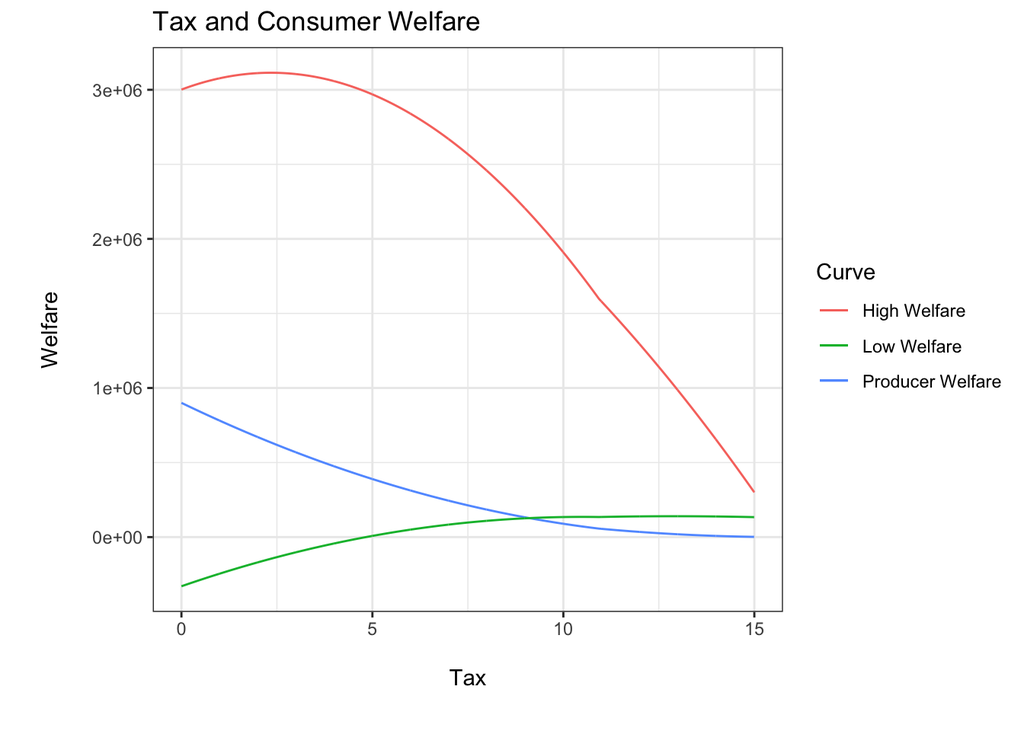

```r
ggplot()+
  geom_line(data=tax_df,aes(x=tax,y=producer_welfare,color="Producer Welfare"))+
  geom_line(data=tax_df,aes(x=tax,y=high_welfare,color="High Welfare"))+
  geom_line(data=tax_df,aes(x=tax,y=low_welfare,color="Low Welfare")) +
  labs(title = "Tax and Consumer Welfare", x = "Tax", y = "Welfare", colour = "Curve") +
  theme(plot.title = element_text(hjust = 0.5)) +
  theme_bw() +
  theme(axis.title.y = element_text(margin = margin(t = 0, r = 15, b = 0, l = 15))) +
  theme(axis.title.x = element_text(margin = margin(t = 15, r = 0, b = 15, l = 0)))
```

2. Overall welfare of “Low” income consumers
3. Gas producers
5. A new electric car technology is invented and it lowers the demand curves of all income groups by half (vertically). Under these new demand curves, what are the effects on:

```r
# assert new demand curves divided by 50 vertically
I1_h<-  lm_low$coefficients[1]/2
I2_h<-  lm_high$coefficients[1]/2

low_demand_h <- function(q)  I1_h + S1*q
high_demand_h<- function(q) I2_h + S2*q
```

```r
# Determines the 'dominate' curve for new curves.
demand_dom_h <- function(q){
  if (I1_h==I2_h){0}
  else if(I1_h>I2_h){low_demand_h(q)}
  else if(I2_h>I1_h){high_demand_h(q)}
}
# Determines q such that the new high demand and low demand are equal. #Used to find the kink in the curve.
intersect_point_h <- abs(uniroot(function(q){high_demand_h(q)-low_demand_h(0)},
                            interval = c(0,1),extendInt = "yes")$root)

# functional defintion of new aggregate demand
# the function itself. When q is less than the interset, returns the 'dominant'
agg_demand_h <- function(q) {ifelse(q<intersect_point_h,demand_dom_h(q),
                                  lm_agg$coefficients[1]/2 + (lm_agg$coefficients[2]*q))
}
agg_demand_h <- function(q) {ifelse(q<intersect_point_h,demand_dom(q),((S2*I1_h+S1*I2_h)/(S2+S1))+((S1*S2)/(S1+S2))*q)
                                  #lm_agg$coefficients[1] + (lm_agg$coefficients[2]*q))
}
demand_dom_x_intersect_h <- uniroot(demand_dom_h,
                                  interval = c(0,1),
                                  extendInt = "yes")$root
```

Aggregate Curve when Demand is decreased by 50%

$P=7.902-2.7\times 10^{-5}Q \text{ when }Q<75,395$

```r
# find intersect of high & Low curves at P = $3.00
high_curve_intersect_h <- uniroot(function(q){high_demand_h(q)-current_price},interval = c(0,1),extendInt = "yes")$root

low_curve_intersect_h <- uniroot(function(q){low_demand_h(q)-current_price},interval = c(0,1),extendInt = "yes")$root
```

```r
#New Agg curve intersect with supply curve P = 440637.96
agg_curve_intersect_h <- uniroot(function(q){agg_demand_h(q)-current_price},interval = c(0,1),extendInt = "yes")$root
adjusted_tax<- supply(agg_curve_intersect_h)
```

```r
# integrate under each MEC from 0 to the new agggrate curve intersect with supply curve
local_env_cost_h <- integrate(local_env_cost_curve, 0, agg_curve_intersect_h)$value

global_env_cost_h <-  integrate(global_env_cost_curve, 0, agg_curve_intersect_h)$value
```

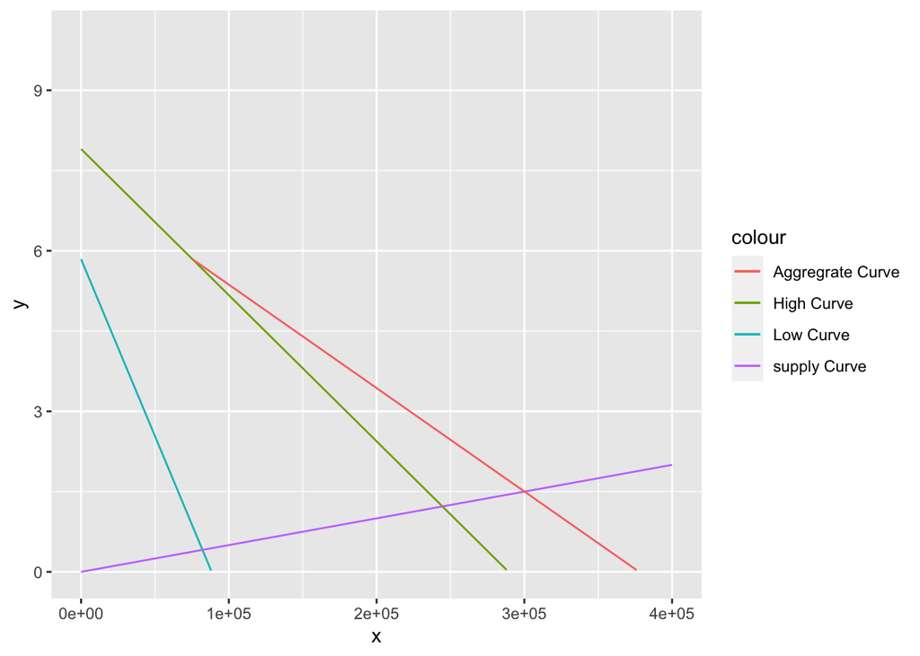

```r
# Visualize
ggplot()+
  stat_function(aes(x=0, color = "Low Curve"), fun = low_demand_h)+
  stat_function(aes(x=0, color = "High Curve"), fun = high_demand_h)+
  stat_function(aes(x=0, color = "supply Curve"), fun = supply)+ stat_function(aes(x=0, color = "Aggregrate Curve"), fun = agg_demand_h)+
xlim(0,400000)+
  scale_y_continuous(breaks=c(0,3,6,9,12,15,18),limits = c(0,10))
```

```r
consumption_difference<- agg_curve_intersect_h - agg_curve_intersect
# intercept w/ electric cars = 293,741; is smaller than intercept without electric cars
```

```r
# Find Price from no electric car aggregate curve when Q*= 293,741 electric car Q*
p_tax_increase <- agg_demand(agg_curve_intersect_h)
```

```r
# Solve p = supply()+ tax; for tax by rearranging now that we know our P* and Q* in the no electric cars scenario
increase_tax<- p_tax_increase- supply_slope*agg_curve_intersect_h
supply_increase_tax <- function(q){supply(q)+increase_tax}

#Agg curve intersect with adjusted tax supply curve
agg_tax_increase_curve_intersect <- uniroot(function(q){agg_demand(q)-supply_increase_tax(q)},interval = c(0,1),extendInt = "yes")$root

# Check that environmental cost is equal for both scenarios with new_tax
#Environmental Without electric cars + new tax
local_env_cost_increase_tax <- integrate(local_env_cost_curve, 0, agg_tax_increase_curve_intersect)$value

# 440611.82
```

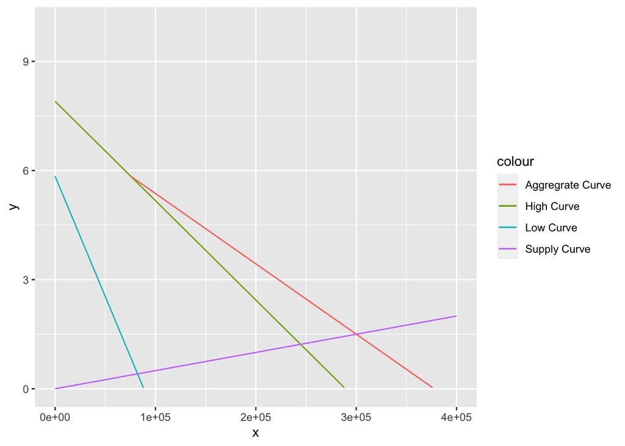

```r
ggplot()+
  stat_function(aes(x=0, color = "Low Curve"), fun = low_demand_h)+
  stat_function(aes(x=0, color = "High Curve"), fun = high_demand_h)+
  stat_function(aes(x=0, color = "Supply Curve"), fun = supply)+ stat_function(aes(x=0, color = "Aggregrate Curve"), fun = agg_demand_h)+
xlim(0,400000)+
  scale_y_continuous(breaks=c(0,3,6,9,12,15,18),limits = c(0,10))
```